# STA207 Final Project

Sixue Cheng

3/10/2022

# 1 Background

In the end of 2019, a world-changing pandemic occurred and is still spreading, affecting countries and people around the world. The COVID-19 epidemic has brought a lot of impacts on us in many aspect: many people died in the pandemic, a lot of people get unemployed, economic downturn, high cost of health care, a lot of palce shutdown, our way of life has changed a lot during this period, etc. Rather than wishing the pandemic had never happened, we should reflect on what has happened in this pandemic to learn from what we could do when facing such situation, and perhaps what we can do to mitigate the damage.

# 2 Introduction

Since COVID-19 breakout and stay-at-home order, we can not be outdoor for restaurants, which, in turn, caused a rush in purchasing necessities of life. This action by people is very likely to cause volatility in the grocery commodities price. Also from my personal experience and feeling in this pandemic, our cost of living has increased a lot, especially when it comes to food. In this report, I want to using COVID-19 related data along with the grocery commodities price data, analyze whether COVID-19 has any impact on grocery goods price.

# 3 Project goal

Analyzing whether COVID-19 has impact on grocery commodities, specifically beef price through descriptive analysis and statistical inference analysis. Evaluate what aspects will affect beef wholesale price, and evaluate their association effect.

# 4 Introduction of data

## 4.1 WHO COVID-19 Data

First, We will explore the WHO COVID-19 data. This data set is maintained by WHO and updated constantly.

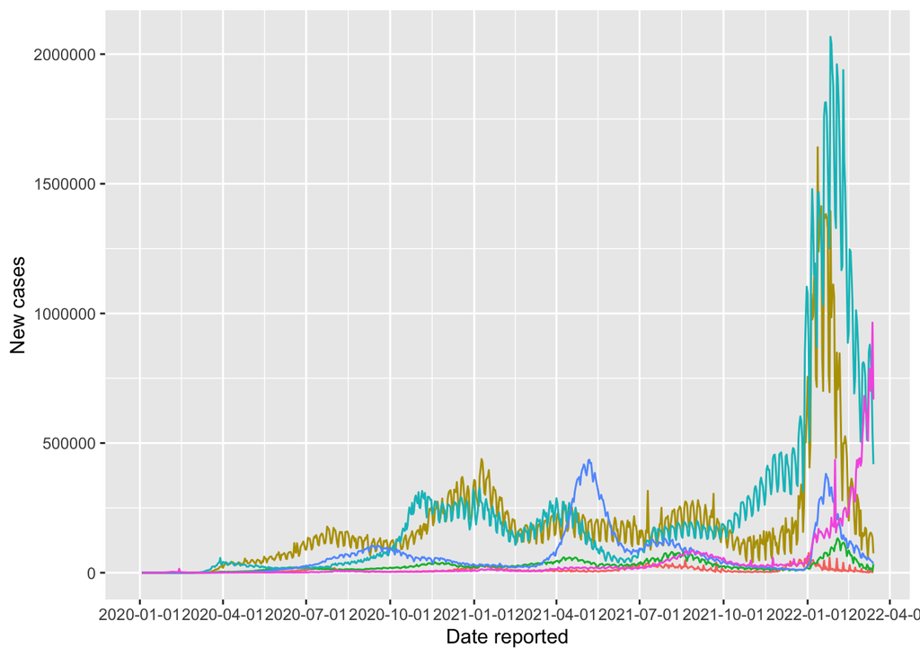

[figure not shown]

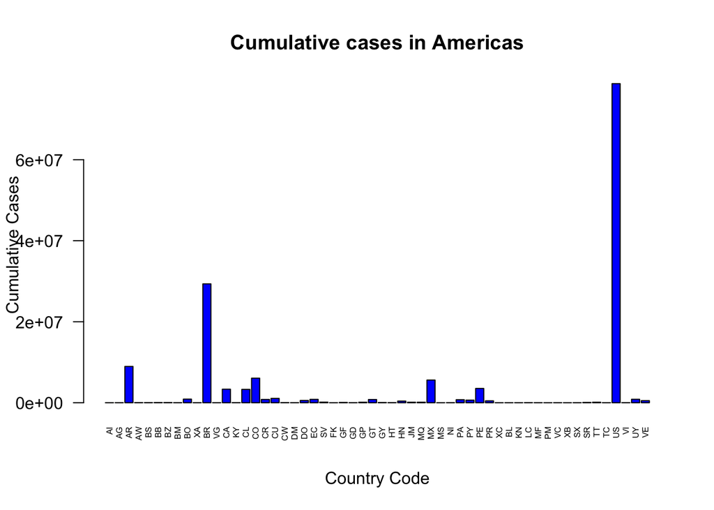

Since United States of America have largest cumulative cases and cumulative deaths in the Americas Region. Obviously, it’s very likely that COVID-19 will bring a lot of impact to this country.

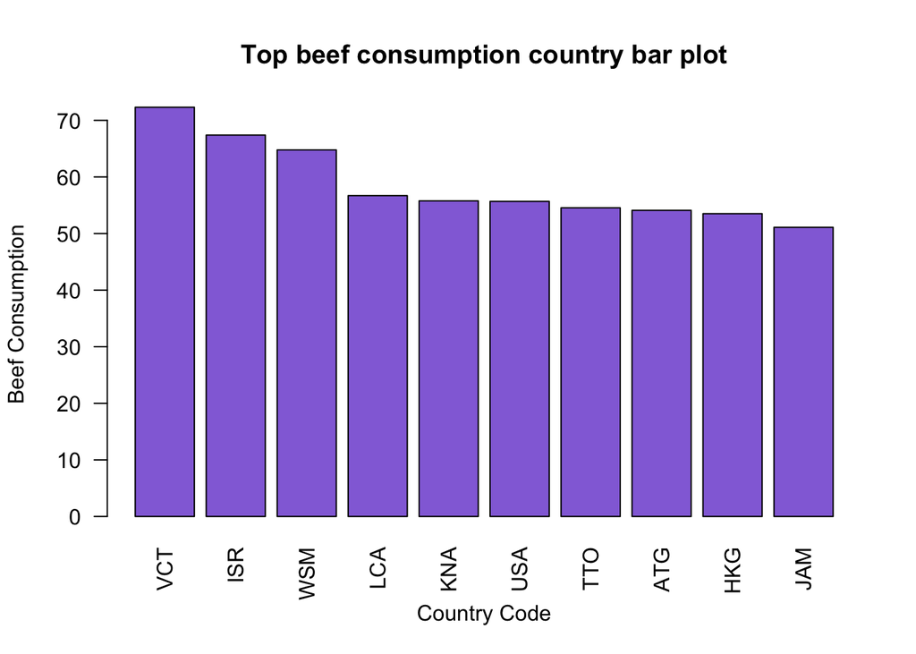

From the plot above, we can see United States is a large beef consumption country. Since my interests is analyzing the COVID-19 impact on beef price, The United States has largest cumulative cases around the world and top 10 beef consumption around the world, which indicates that The United States could be a prefect sample to preform my analysis.  
In the following, I extract the United States data from the COVID data set, and review the background of the corona virus pandemic.

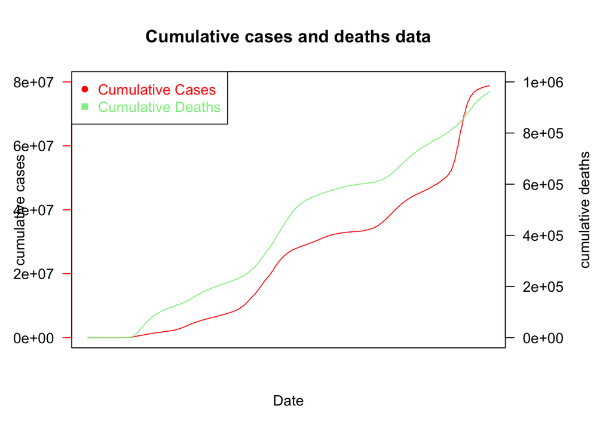

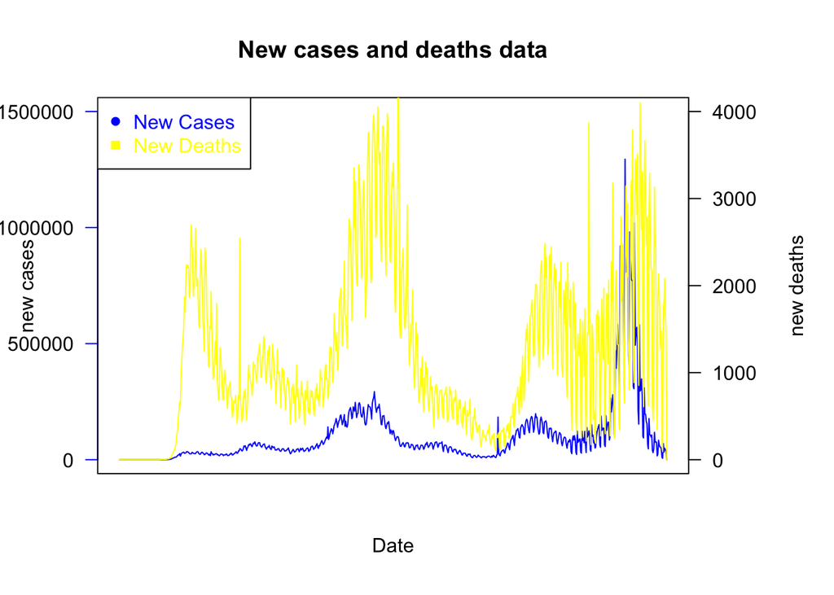

## 4.2 Grocery Commodities Data:

### 4.2.1 Wholesale price

There are a lot of wholesale meat price in this data set, for the sake of convenience, I decided to select “Choice 1-3, 600 - 900 lbs.” price to analyze. The reason I chose this variable is this kind of meat is most common in the grocery store, it align with my target that finding the COVID-19 impact on our life. In the original data set, this price is the first column. This data is the response variable of my model.

[output not shown]

### 4.2.2 Live stock cattle price

Live stock cattle price is the purchasing cost of beef, and the merchants and grocery stores could decide the wholesale price based on their purchasing cost, which means it’s obvious live stock cattle price is related to wholesale price. Since there are 7 cattle price in the original data set, the only difference is the quality of the cattle, I decide to use average of live stock cattle price to represent live stock price.

[output not shown]

### 4.2.3 Government Stringency Index

The COVID-19 does not directly impact price. However, the government will response to COVID-19 situation. In the United States, the government issued a lot policies in the COVID-19 pandemic, such as stay-at-home order, the worker who got illness could go to work, etc. Stay-at-home order made people panic, as a result, stocked up their daily supply. Since a lot of people try to purchase goods at the same time, while the supply chain could not follow up such high demand in short time, which caused the instability of wholesale price. Also, the policy that workers got illness could go to work caused a shortage of workers in supply chain, fewer people could slaughter cattle, box and ship cattle. To some extent, this will result instability in the wholesale price. Based on those reasons, the Government Stringency Index could be a related variable to wholesale price data.

# 5 Descriptive Analysis

Since our data is time sensitive, instead of using histogram plot, I decided to use line plot for visualization in descriptive analysis.

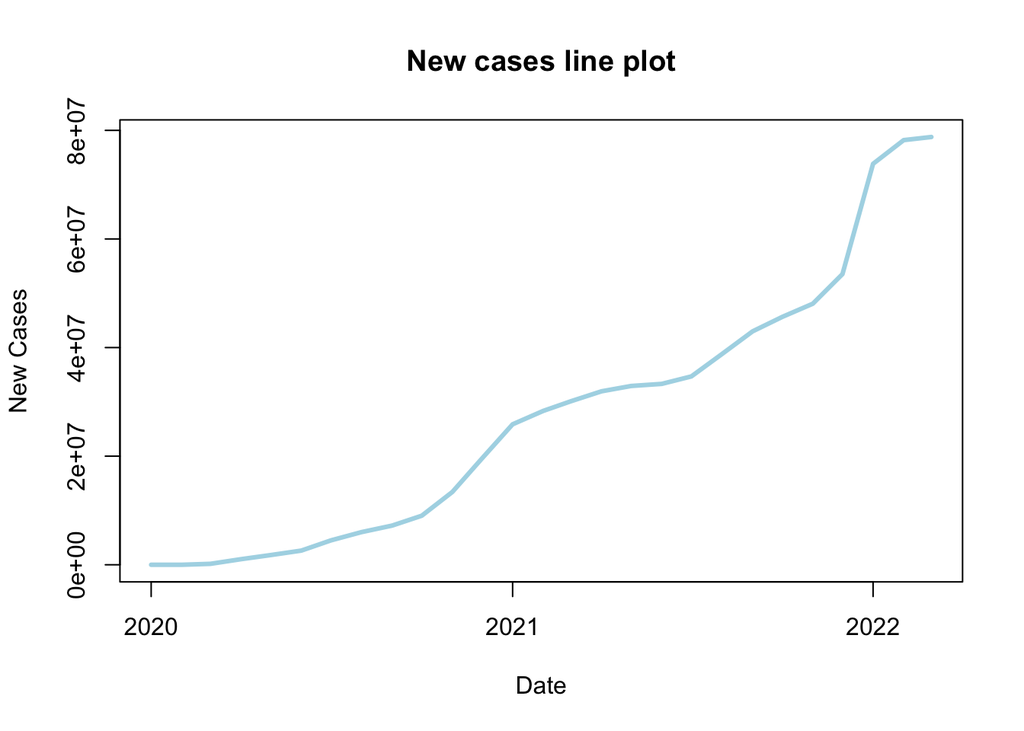

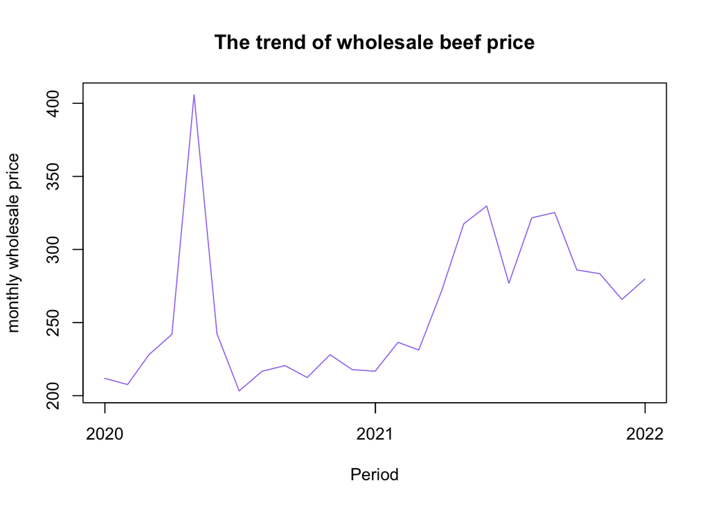

Average, mean, median, max and min in wholesale beef price and COVID-19 new cases in the United States, and correlation between those two variables.

```
##    New_cases        wholesale_price
##  Min.   :       3   Min.   :203.2
##  1st Qu.: 4489467   1st Qu.:217.8
##  Median :25868400   Median :241.9
##  Mean   :23416106   Mean   :259.1
##  3rd Qu.:34686490   3rd Qu.:283.5
##  Max.   :73840585   Max.   :405.8
```

```
##                 New_cases wholesale_price
## New_cases       1.0000000       0.4063298
## wholesale_price 0.4063298       1.0000000
```

From the correlation of COVID-19 new cases and price data, we can see that the severity of COVID-19 situation could not explain the wholesale price change. To interpret this result, I think the COVID-19 situation will not directly impact the wholesale price of beef. In the following is the line plot of both new cases data and wholesale price data.

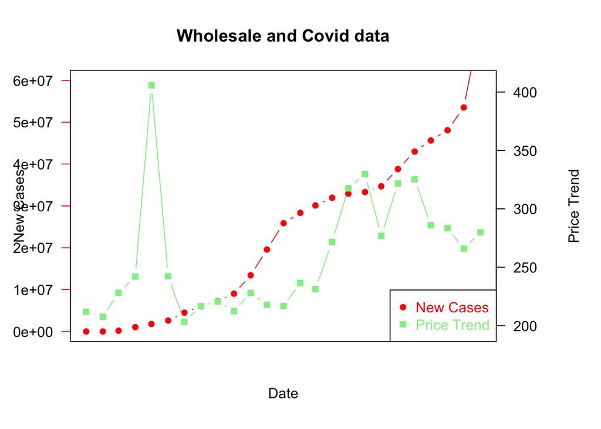

We can see that the new cases are steadily rising, while there is some volatility in wholesale price trend.

Summary Statistics of all variables

```
##  wholesale_price  cattle_price   stringency_index   New_cases
##  Min.   :203.2   Min.   :125.1   Min.   : 0.00    Min.   :       3
##  1st Qu.:217.8   1st Qu.:132.7   1st Qu.:50.46    1st Qu.: 4489467
##  Median :241.9   Median :138.1   Median :61.57    Median :25868400
##  Mean   :259.1   Mean   :139.5   Mean   :55.04    Mean   :23416106
##  3rd Qu.:283.5   3rd Qu.:144.9   3rd Qu.:68.98    3rd Qu.:34686490
##  Max.   :405.8   Max.   :163.7   Max.   :75.46    Max.   :73840585
```

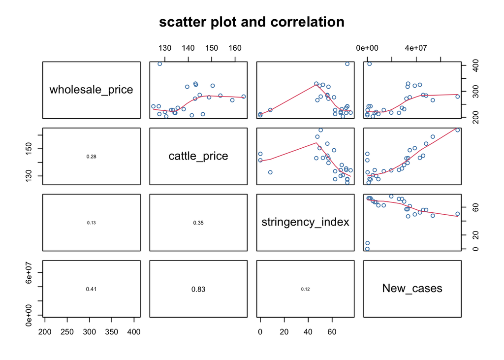